# Regresión lineal Datos Vino

## Preliminares

En este documento ajustaremos algunos modelos de regresión lineal a los datos sobre venta de vinos. Para ello, utilizamos el conjunto de datos que generamos tras la depuración, asegurando un conjunto de datos “limpios” y exentos de ciertos peligros.

En primer lugar se fija el directorio de trabajo donde tenemos las funciones y los datos.

Procedemos a la lectura de los datos depurados. Ya que vamos a hacer cosas como evaluación de las relaciones entre los predictores y la respuesta o creación masiva de transformaciones para< conseguir linealidad, lo mejor es separar las respuestas y quedarnos con el input depurado, de esta forma podemos aplicar una misma función a todo el conjunto sin peligro de transformar las respuestas y cosas raras que puedan suceder.

```r
# Parto de los datos sin atípicos ni ausentes guardados
datos<-readRDS("F:/Documentos/Master Comercio 2021-22/Online_Material Minería de Datos_Otoño2021/Dia1_MD&Depuracion/datosVinoDep.RDS")

varObjCont<-datos$varObjCont
varObjBin<-datos$varObjBin
input<-datos[,-(1:2)]
```

No es mala idea generar un par de variables de “control” para la evaluación de los efectos de los predictores frente a la respuesta. La idea es la siguiente: si generamos variables en el más estricto sentido aleatorio (por ejemplo siguiendo una distribución uniforme[0,1]) cualquier relación que estas presenten con la variable respuesta serán debidas puramente al azar, con lo que se pueden considerar relaciones espurias, es decir, falsas.

Por tanto, ya sea en la inspección preliminar de relaciones con la respuesta mediante correlación (relación lineal, válido para continua-continua) o VCramer (asociación en tablas de contingencia, válido para cruce de variables categóricas/nominales o continuas tramificadas) o bien en los propios modelos de regresión, las variables que presenten una menor relación con la respuesta que las variables de control, tendrán una sombra de sospecha sobre la veracidad de esa relación y probablemente serán descartadas, al menos en su estado original (siempre se pueden tratar de transformar, tramificar etc)

```r
# Creo la variable aleatoria
input$aleatorio<-runif(nrow(input))

input$aleatorio2<-runif(nrow(input))
```

## Estudio descriptivo de relaciones con la respuesta

En este apartado intentaremos descubrir a priori las relaciones marginales de las variables con la variable objetivo para hacernos una idea de cuales de ellas serán potencialmente influyentes en los modelos de regresión que ajustemos.

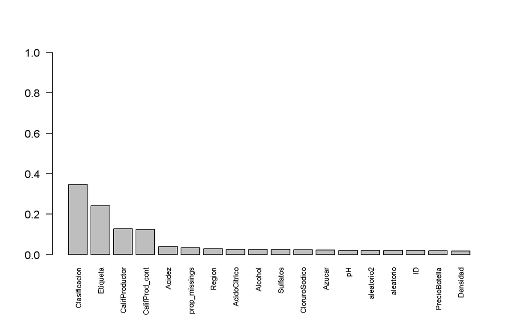

```r
#Obtengo la importancia de las variables.
# Falla si hay alguna variable cuantitativa
# con menos de 6 valores diferentes
graficoVcramer(input,varObjCont)
```

Aparecen las nominales y también prop_missings (algo que comprobaremos luego en modelo). A partir de acidez…las relaciones no son más fuertes que las debidas al azar (al menos a nivel marginal). Sospechamos que las demás variables tendrán baja influencia a no ser que se produzca efecto potenciador por la presencia conjunta de varios efectos en un mismo modelo (cosa que valoraremos llegado el momento).

Vamos a ver gráficamente las relaciones de las nominales sobre la continua. Podemos hacer uso del boxplot e histograma para target binaria ya que en realidad tiene implementado una comparación de continua con categórica en gráfico. En este caso lo utilizaremos de manera inversa al especificado en la fórmula de la función, indicando primero la objetivo continua y luego la nominal del input.

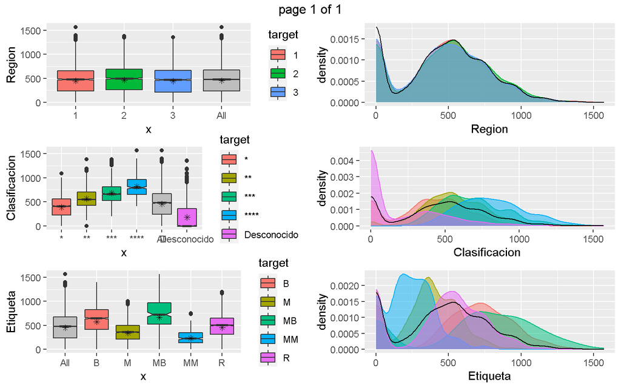

```r
#Veo gráficamente el efecto de dos variables cualitativas sobre la binaria
b1<-boxplot_targetbinaria(varObjCont,input$Region,"Region") #esta no influye
b2<-boxplot_targetbinaria(varObjCont,input$Clasificacion,"Clasificacion") #esta sí influye
b3<-boxplot_targetbinaria(varObjCont,input$Etiqueta,"Etiqueta") #esta sí influye

h1<-hist_targetbinaria(varObjCont,input$Region,"Region") #esta no influye
h2<-hist_targetbinaria(varObjCont,input$Clasificacion,"Clasificacion") #esta sí influye
h3<-hist_targetbinaria(varObjCont,input$Etiqueta,"Etiqueta") #esta sí influye

marrangeGrob(list(b1,b2,b3,h1,h2,h3),nrow = 3,ncol = 2)
```

A la vista de los gráficos, es evidente que el solapamiento de las distribuciones del beneficio del vino en relación a la región de origen del mismo indica la falta de influencia de la variable región en dicho beneficio, por lo que diremos que este predictor no tiene capacidad de discriminación frente a la respuesta y no será importante para el modelo.

En cambio, las variables clasificación y Etiqueta presentan distribuciones de beneficio muy distintas en sus categorías, por lo que estas categorías pueden servir para estimar dicho beneficio. Sospechamos que serán importantes de cara al modelado.

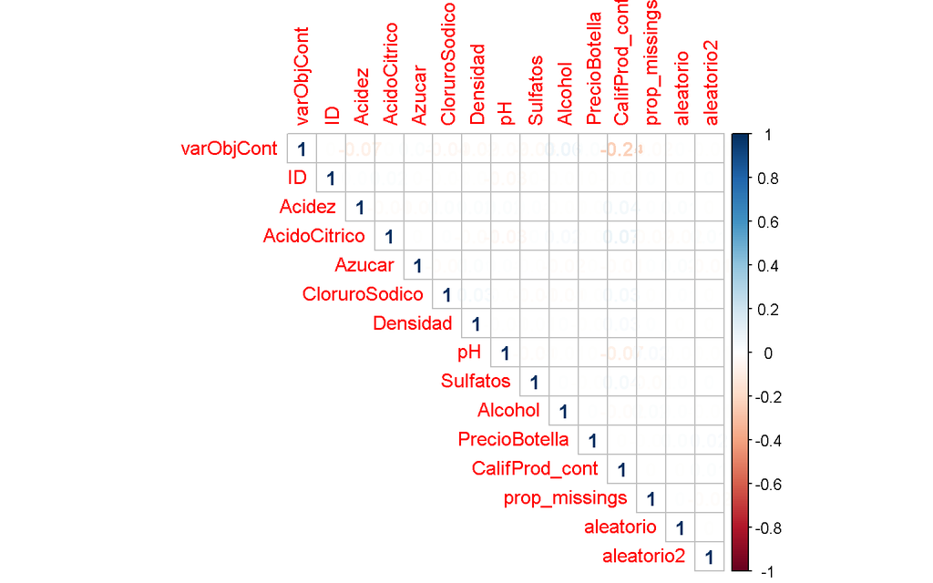

```r
# Gráfico de correlaciones entre las variables continuas
corrplot(cor(cbind(varObjCont,Filter(is.numeric, input)), use="pairwise", method="pearson"), method = "number",type = "upper")
```

En el gráfico de correlaciones se intuye la baja relación lineal presente entre las variables del archivo 2 a 2. Esto nos hace pensar que las variables continuas, a diferencia de las categóricas, no van a tener demasiada influencia en los modelos de regresión frente a la respuesta (véase el poco color que presenta la fila 1). Por otro lado, podemos estar respirar con cierta tranquilidad ante el hecho de la baja relación entre los predictores (véase la ausencia de color en todo el gráfico), cosa que evitará problemas de colinealidad en los modelos.

Es evidente que, las relaciones de cada variable con su transformada han de ser muy elevadas, ya que hay un mecanismo que genera una en función exacta de la otra, por lo que esto es normal.

**Nota:** La principal precaución que hay que tener es no considerar un modelo completo con todas al mismo tiempo puesto que se pueden generar los problemas de colinealidad. Solamente utilizaremos el set completo de variables cuando hagamos un proceso de selección automática de variables, proceso en el cual se elegirán las que más R2 aporten al modelo.

### Transformaciones de las variables continuas

El principal objetivo de las transformaciones de las variables continuas es conseguir linealidad frente a la variable objetivo. De esta forma se prueban las transformaciones típicas (log, exp, potencias y raíces) y se escoge aquella que mayor coeficiente de correlación presenta con la respuesta continua.

```r
#Busco las mejores transformaciones para las variables numéricas con respesto a los dos tipos de variables
input_cont<-cbind(input,Transf_Auto(Filter(is.numeric, input),varObjCont))

saveRDS(data.frame(input_cont,varObjCont),"todo_cont_Vino.RDS")
```

Podemos comprobar si las transformaciones han aumentado el valor de correlación lineal con la respuesta.

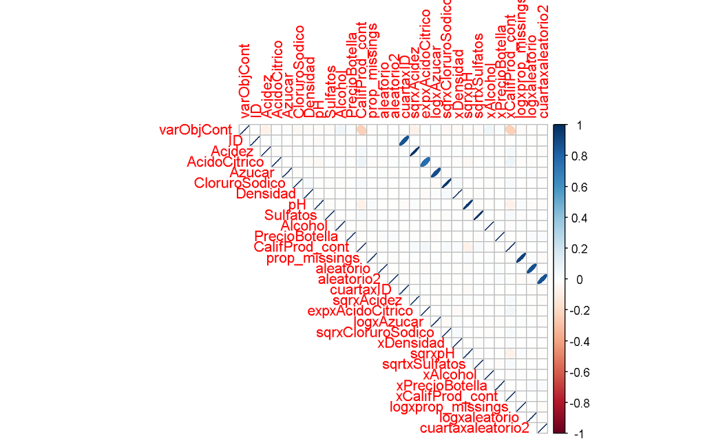

```r
# Gráfico de correlaciones entre las variables continuas (incluidas transformaciones)
corrplot(cor(cbind(varObjCont,Filter(is.numeric, input_cont)), use="pairwise", method="pearson"), method = "ellipse",type = "upper")
```

No parece que haya mejorado mucho…Este estudio nos lleva a pensar que las variables continuas no van a aportar mucho a nuestro modelo de regresión, si bien puede suceder que en presencia de otras variables (por ejemplo las categóricas) la influencia de éstas pueda aumentar debido al distinto comportamiento (pendiente) que presenten con la respuesta en los distintos grupos que forma la variable categórica.

Por este motivo, es positivo complementar este análisis descriptivo con la información que dan los modelos sobre la importancia de variables, ya que dentro de modelo, la influencia de la variable se entiende a niveles constantes de todas las demás presentes en el mismo.

En cualquier caso, una vía que se puede explorar aquí para conseguir mayor influencia de las continuas es intentar tramificarlas (pasarlas a categóricas) de tal manera que se puedan descubrir patrones muy alejados d la linealidad que esta puedan contener. En el mundo de la tramificación existen dos estrategias fundamentales,

1. tramos ad-hoc para una mejor interpretabilidad (por ejemplo tramos de edad acordes a los que se utilizan en las estadísticas oficiales) en los que normalmente se realizan particiones más o menos equidistantes o basadas en un fundamento anterior.
2. tramos que maximicen cierta relación con la variable objetivo. Se pueden generar los puntos de corte de la variable a tramificar tales que los grupos creados sean lo más distintos entre sí en distribución de la variable respuesta, con lo que se “aseguran” tramos con capacidad de discriminar frente al objetivo. Suelen funcionar bien este tipo de tramificaciones pero tienen cierto peligro de sobreajustar a los datos de entrenamiento…Una de las formas de hacerlo es mediante árboles de regresión/clasificación.

Un árbol realiza particiones binarias de las variables con la premisa de encontrar las mayores diferencias entre los grupos que va formando, justo lo que buscamos!

```r
# Arbol para tramificar azucar
tree_azucar<-rpart::rpart(varObjCont~Azucar, data = datos, cp=0.005)
tree_azucar
```

```
## n= 6365
##
## node), split, n, deviance, yval
##       * denotes terminal node
##
## 1) root 6365 605207200 452.3802
##   2) Azucar< 4.48975 3222 323203600 435.1741
##     4) Azucar>=1.6474 969 110011800 372.0000 *
##     5) Azucar< 1.6474 2253 207661200 462.3449 *
##   3) Azucar>=4.48975 3143 280071900 470.0188 *
```

Vamos a crear la variable que propone el árbol, categórica con 3 niveles y los puntos de corte comentados. el argumento where del árbol contiene esta variable, pero sin las etiquetas apropiadas. Comprobamos y ponemos las correctas.

```r
# puntos de corte en 1.61 y 4.46. Tres grupos.
table(tree_azucar$where)
```

```
##
##    3    4    5
##  969 2253 3143
```

```r
# Los grupos están ya ordenados pero se llaman 3 4 y 5

# Añadimos la variable tramificada al dataset
input$Azucar_tree<-factor(tree_azucar$where)
```

```r
# Cambiamos los niveles (los ordeno correctamente!!)
levels(input$Azucar_tree) = c('1.62-4.45','<1.62','>4.45')

# Comprobamos
table(input$Azucar_tree)
```

```
##
## 1.62-4.45     <1.62     >4.45
##       969      2253      3143
```

```r
# Ordenamos niveles
input$Azucar_tree<-factor(input$Azucar_tree, levels = c('<1.62','1.62-4.45','>4.45'))

# Comprobamos
table(input$Azucar_tree)
```

```
##
##     <1.62 1.62-4.45     >4.45
##      2253       969      3143
```

Vamos a valorar la capacidad a priori de esta variable.

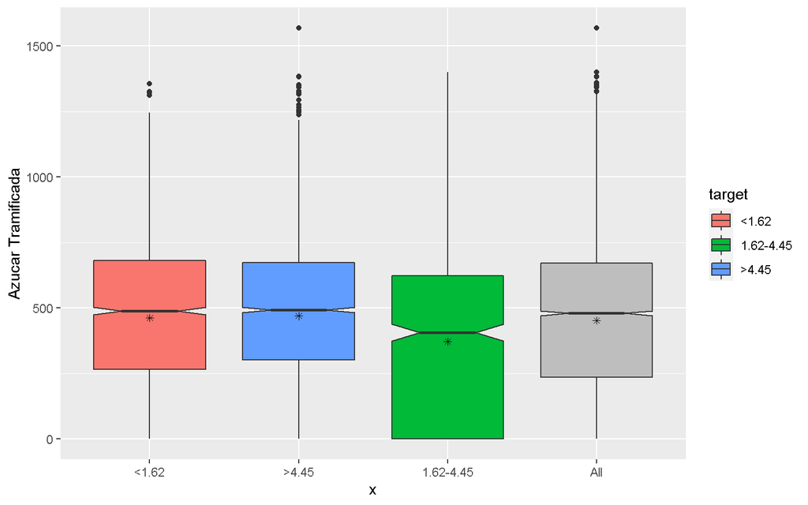

```r
boxplot_targetbinaria(varObjCont,input$Azucar_tree,"Azucar Tramificada")
```

El tramo de valores intermedios es claramente distinto a los otros. Existe cierta diferencia entre el 2 y el 3los extremos pero no queda claro si será significativa. Habrá que valorarlo en modelo.

## Modelos de regresión lineal para la predicción del beneficio del vino

En esta sección se ajustan distintos modelos de regresión lineal para predecir el beneficio de los vinos. En primer lugar tomamos la partición training (donde ajustamos el modelo) y test (donde probamos su capacidad).

### Partición training-test

```r
## Comienzo con la regresión lineal
todo<-data.frame(input,varObjCont)

#Obtengo la partición
set.seed(123456)
trainIndex <- createDataPartition(todo$varObjCont, p=0.8, list=FALSE)
data_train <- todo[trainIndex,]
data_test <- todo[-trainIndex,]
```

### Modelo completo de referencia

Probamos primero con las variables continuas de erigen para las que tenemos otras posibilidades contempladas, en este caso Azucar y Calif_Prod.

```r
#Construyo un modelo preliminar con todas las variables
modelo1<-lm(varObjCont~.- Azucar_tree- CalifProductor-ID ,data=data_train)
summary(modelo1)
```

```
##
## Call:
## lm(formula = varObjCont ~ . - Azucar_tree - CalifProductor -
##     ID, data = data_train)
##
## Residuals:
##     Min      1Q  Median      3Q     Max
## -668.21 -163.41  -17.14  148.43  967.64
##
## Coefficients:
##                            Estimate Std. Error t value Pr(>|t|)
## (Intercept)               688.38516  138.04806   4.987 6.35e-07 ***
## Acidez                    -17.21194    4.44731  -3.870 0.000110 ***
## AcidoCitrico               -0.06762    4.09117  -0.017 0.986814
## Azucar                      0.07737    0.10299   0.751 0.452526
## CloruroSodico             -29.19383   10.75314  -2.715 0.006652 **
## Densidad                  -93.75747  136.57308  -0.687 0.492429
## pH                         -9.55611    5.16217  -1.851 0.064202 .
## Sulfatos                   -3.61526    3.74624  -0.965 0.334572
## Alcohol                     2.12945    0.90867   2.343 0.019144 *
## EtiquetaM                -138.52007    9.38058 -14.767  < 2e-16 ***
## EtiquetaMB                 61.53536   17.49290   3.518 0.000439 ***
## EtiquetaMM               -208.17264   17.39170 -11.970  < 2e-16 ***
## EtiquetaR                 -75.09215    8.16268  -9.199  < 2e-16 ***
## Clasificacion**           140.77460    8.86799  15.874  < 2e-16 ***
## Clasificacion***          240.04596   10.30065  23.304  < 2e-16 ***
## Clasificacion****         331.99604   16.21660  20.473  < 2e-16 ***
## ClasificacionDesconocido -216.40292    8.95771 -24.158  < 2e-16 ***
## Region2                     4.00892    7.77545   0.516 0.606165
## Region3                     3.38520    7.68280   0.441 0.659506
## PrecioBotella               0.37135    2.11633   0.175 0.860719
## CalifProd_cont            -31.57102    2.45013 -12.885  < 2e-16 ***
## prop_missings              -9.53788   75.66347  -0.126 0.899692
## aleatorio                  -3.92538   10.89166  -0.360 0.718561
## aleatorio2                -12.60104   10.90943  -1.155 0.248120
## ---
## Signif. codes:  0 '***' 0.001 '**' 0.01 '*' 0.05 '.' 0.1 ' ' 1
##
## Residual standard error: 224.4 on 5070 degrees of freedom
## Multiple R-squared:  0.4735, Adjusted R-squared:  0.4711
## F-statistic: 198.2 on 23 and 5070 DF,  p-value: < 2.2e-16
```

```r
Rsq(modelo1,"varObjCont",data_train)
```

```
## $r2
## [1] 0.4734694
##
## $r2_adj
## [1] 0.4709765
```

```r
Rsq(modelo1,"varObjCont",data_test)
```

```
## $r2
## [1] 0.4808927
##
## $r2_adj
## [1] 0.4708938
```

```r
modelo1_t<-lm(varObjCont~.- Azucar- CalifProductor-ID,data=data_train)
summary(modelo1_t)
```

```
##
## Call:
## lm(formula = varObjCont ~ . - Azucar - CalifProductor - ID, data = data_train)
##
## Residuals:
##     Min      1Q  Median      3Q     Max
## -671.78 -163.31  -18.09  146.83  965.33
##
## Coefficients:
##                           Estimate Std. Error t value Pr(>|t|)
## (Intercept)               703.6108   137.8363   5.105 3.43e-07 ***
## Acidez                    -16.4163     4.4425  -3.695 0.000222 ***
## AcidoCitrico               -0.5150     4.0850  -0.126 0.899687
## CloruroSodico             -28.0200    10.7360  -2.610 0.009083 **
## Densidad                 -112.3624   136.4095  -0.824 0.410141
## pH                         -8.8759     5.1547  -1.722 0.085148 .
## Sulfatos                   -3.1973     3.7409  -0.855 0.392757
## Alcohol                     2.2089     0.9072   2.435 0.014938 *
## EtiquetaM                -137.6484     9.3612 -14.704  < 2e-16 ***
## EtiquetaMB                 61.6079    17.4592   3.529 0.000421 ***
## EtiquetaMM               -208.4821    17.3587 -12.010  < 2e-16 ***
## EtiquetaR                 -74.5698     8.1458  -9.154  < 2e-16 ***
## Clasificacion**           140.3995     8.8500  15.864  < 2e-16 ***
## Clasificacion***          240.2487    10.2812  23.368  < 2e-16 ***
## Clasificacion****         332.3677    16.1887  20.531  < 2e-16 ***
## ClasificacionDesconocido -214.6696     8.9493 -23.987  < 2e-16 ***
## Region2                     4.0524     7.7609   0.522 0.601581
## Region3                     3.1914     7.6693   0.416 0.677331
## PrecioBotella               0.4555     2.1124   0.216 0.829273
## CalifProd_cont            -30.4300     2.4594 -12.373  < 2e-16 ***
## prop_missings              -9.8146    75.5301  -0.130 0.896617
## aleatorio                  -3.7744    10.8708  -0.347 0.728448
## aleatorio2                -13.7254    10.8920  -1.260 0.207676
## Azucar_tree1.62-4.45      -37.0407     9.7313  -3.806 0.000143 ***
## Azucar_tree>4.45            4.5765     6.9347   0.660 0.509315
## ---
## Signif. codes:  0 '***' 0.001 '**' 0.01 '*' 0.05 '.' 0.1 ' ' 1
##
## Residual standard error: 224 on 5069 degrees of freedom
## Multiple R-squared:  0.4755, Adjusted R-squared:  0.4731
## F-statistic: 191.5 on 24 and 5069 DF,  p-value: < 2.2e-16
```

```r
Rsq(modelo1_t,"varObjCont",data_train)
```

```
## $r2
## [1] 0.475542
##
## $r2_adj
## [1] 0.4729549
```

```r
Rsq(modelo1_t,"varObjCont",data_test)
```

```
## $r2
## [1] 0.4858219
##
## $r2_adj
## [1] 0.4754971
```

El modelo mejora en todo, R2 ajustado (a pesar del aumento de 1 parámetro), significación de la variable y capacidad de generalización al test. Elegiremos quedarnos con esta variable tramificada en lugar de la original.

```r
# Nos fijamos en la importancia de las variables. Podemos sacar un gráfico
# que muestra lo que se pierde en R2 en train al quitarlas del modelo
modelEffectSizes(modelo1_t)
```

```
## lm(formula = varObjCont ~ . - Azucar - CalifProductor - ID, data = data_train)
##
## Coefficients
##                         SSR df pEta-sqr dR-sqr
## (Intercept)    1.307036e+06  1   0.0051     NA
## Acidez         6.849174e+05  1   0.0027 0.0014
## AcidoCitrico   7.971242e+02  1   0.0000 0.0000
## CloruroSodico  3.416638e+05  1   0.0013 0.0007
## Densidad       3.403321e+04  1   0.0001 0.0001
## pH             1.487199e+05  1   0.0006 0.0003
## Sulfatos       3.664191e+04  1   0.0001 0.0001
## Alcohol        2.973320e+05  1   0.0012 0.0006
## Etiqueta       1.701256e+07  4   0.0627 0.0351
## Clasificacion  1.440392e+08  4   0.3616 0.2971
## Region         1.525036e+04  2   0.0001 0.0000
## PrecioBotella  2.332545e+03  1   0.0000 0.0000
## CalifProd_cont 7.679113e+06  1   0.0293 0.0158
## prop_missings  8.469448e+02  1   0.0000 0.0000
## aleatorio      6.046905e+03  1   0.0000 0.0000
## aleatorio2     7.965059e+04  1   0.0003 0.0002
## Azucar_tree    1.033187e+06  2   0.0040 0.0021
##
## Sum of squared errors (SSE): 254256687.3
## Sum of squared total  (SST): 484798924.6
```

```
## lm(formula = varObjCont ~ . - Azucar - CalifProductor - ID, data = data_train)
##
## Coefficients
##                         SSR df pEta-sqr dR-sqr
## (Intercept)    1.307036e+06  1   0.0051     NA
## Acidez         6.849174e+05  1   0.0027 0.0014
## AcidoCitrico   7.971242e+02  1   0.0000 0.0000
## CloruroSodico  3.416638e+05  1   0.0013 0.0007
## Densidad       3.403321e+04  1   0.0001 0.0001
## pH             1.487199e+05  1   0.0006 0.0003
## Sulfatos       3.664191e+04  1   0.0001 0.0001
## Alcohol        2.973320e+05  1   0.0012 0.0006
## Etiqueta       1.701256e+07  4   0.0627 0.0351
## Clasificacion  1.440392e+08  4   0.3616 0.2971
## Region         1.525036e+04  2   0.0001 0.0000
## PrecioBotella  2.332545e+03  1   0.0000 0.0000
## CalifProd_cont 7.679113e+06  1   0.0293 0.0158
## prop_missings  8.469448e+02  1   0.0000 0.0000
## aleatorio      6.046905e+03  1   0.0000 0.0000
## aleatorio2     7.965059e+04  1   0.0003 0.0002
## Azucar_tree    1.033187e+06  2   0.0040 0.0021
##
## Sum of squared errors (SSE): 254256687.3
## Sum of squared total  (SST): 484798924.6
```

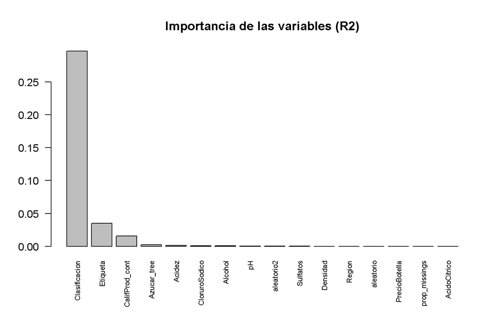

```r
barplot(sort(modelEffectSizes(modelo1_t)$Effects[-1,4],decreasing =T),las=2, cex.names = 0.7,main="Importancia de las variables (R2)")
```

### Modelo con las variables más importantes según Vcramer

```r
modelo2<-lm(varObjCont~Clasificacion+Etiqueta+CalifProd_cont+prop_missings,data=data_train)
summary(modelo2)
```

```
##
## Call:
## lm(formula = varObjCont ~ Clasificacion + Etiqueta + CalifProd_cont +
##     prop_missings, data = data_train)
##
## Residuals:
##     Min      1Q  Median      3Q     Max
## -681.76 -163.70  -16.31  148.90  968.73
##
## Coefficients:
##                          Estimate Std. Error t value Pr(>|t|)
## (Intercept)               573.571     11.845  48.423  < 2e-16 ***
## Clasificacion**           142.766      8.862  16.110  < 2e-16 ***
## Clasificacion***          242.361     10.299  23.533  < 2e-16 ***
## Clasificacion****         336.750     16.220  20.762  < 2e-16 ***
## ClasificacionDesconocido -217.325      8.969 -24.231  < 2e-16 ***
## EtiquetaM                -137.847      9.394 -14.674  < 2e-16 ***
## EtiquetaMB                 62.012     17.500   3.544 0.000398 ***
## EtiquetaMM               -207.520     17.409 -11.920  < 2e-16 ***
## EtiquetaR                 -74.396      8.174  -9.101  < 2e-16 ***
## CalifProd_cont            -31.984      2.437 -13.127  < 2e-16 ***
## prop_missings              -9.577     75.782  -0.126 0.899435
## ---
## Signif. codes:  0 '***' 0.001 '**' 0.01 '*' 0.05 '.' 0.1 ' ' 1
##
## Residual standard error: 224.9 on 5083 degrees of freedom
## Multiple R-squared:  0.4697, Adjusted R-squared:  0.4687
## F-statistic: 450.3 on 10 and 5083 DF,  p-value: < 2.2e-16
```

```r
Rsq(modelo2,"varObjCont",data_train)
```

```
## $r2
## [1] 0.4697222
##
## $r2_adj
## [1] 0.4685744
```

```r
Rsq(modelo2,"varObjCont",data_test)
```

```
## $r2
## [1] 0.4823919
##
## $r2_adj
## [1] 0.4778695
```

### Modelo sin prop_missings

```r
#Pruebo un modelo con menos variables, basándome en la importancia de las variables
modelo3<-lm(varObjCont~Clasificacion+Etiqueta+CalifProd_cont,data=data_train)
summary(modelo3)
```

```
##
## Call:
## lm(formula = varObjCont ~ Clasificacion + Etiqueta + CalifProd_cont,
##     data = data_train)
##
## Residuals:
##     Min      1Q  Median      3Q     Max
## -682.16 -163.96  -16.51  148.82  969.00
##
## Coefficients:
##                          Estimate Std. Error t value Pr(>|t|)
## (Intercept)               573.310     11.663  49.156  < 2e-16 ***
## Clasificacion**           142.765      8.861  16.111  < 2e-16 ***
## Clasificacion***          242.343     10.297  23.536  < 2e-16 ***
## Clasificacion****         336.713     16.216  20.765  < 2e-16 ***
## ClasificacionDesconocido -217.368      8.962 -24.256  < 2e-16 ***
## EtiquetaM                -137.830      9.392 -14.675  < 2e-16 ***
## EtiquetaMB                 62.038     17.497   3.546 0.000395 ***
## EtiquetaMM               -207.539     17.407 -11.923  < 2e-16 ***
## EtiquetaR                 -74.383      8.173  -9.101  < 2e-16 ***
## CalifProd_cont            -31.984      2.436 -13.128  < 2e-16 ***
## ---
## Signif. codes:  0 '***' 0.001 '**' 0.01 '*' 0.05 '.' 0.1 ' ' 1
##
## Residual standard error: 224.9 on 5084 degrees of freedom
## Multiple R-squared:  0.4697, Adjusted R-squared:  0.4688
## F-statistic: 500.4 on 9 and 5084 DF,  p-value: < 2.2e-16
```

```r
Rsq(modelo3,"varObjCont",data_train)
```

```
## $r2
## [1] 0.4697205
##
## $r2_adj
## [1] 0.4686773
```

```r
Rsq(modelo3,"varObjCont",data_test)
```

```
## $r2
## [1] 0.4823857
##
## $r2_adj
## [1] 0.4782776
```

### Modelo con Azucar_tree

```r
#Pruebo un modelo con Azucar tramificada
modelo4<-lm(varObjCont~Clasificacion+Etiqueta+CalifProd_cont+Azucar_tree,data=data_train)
summary(modelo4)
```

```
##
## Call:
## lm(formula = varObjCont ~ Clasificacion + Etiqueta + CalifProd_cont +
##     Azucar_tree, data = data_train)
##
## Residuals:
##     Min      1Q  Median      3Q     Max
## -684.64 -163.21  -16.87  148.65  966.47
##
## Coefficients:
##                          Estimate Std. Error t value Pr(>|t|)
## (Intercept)               573.121     12.309  46.561  < 2e-16 ***
## Clasificacion**           142.221      8.845  16.080  < 2e-16 ***
## Clasificacion***          242.519     10.276  23.600  < 2e-16 ***
## Clasificacion****         336.825     16.189  20.806  < 2e-16 ***
## ClasificacionDesconocido -215.491      8.952 -24.071  < 2e-16 ***
## EtiquetaM                -137.108      9.375 -14.626  < 2e-16 ***
## EtiquetaMB                 61.702     17.463   3.533 0.000414 ***
## EtiquetaMM               -207.840     17.372 -11.964  < 2e-16 ***
## EtiquetaR                 -73.990      8.157  -9.071  < 2e-16 ***
## CalifProd_cont            -30.801      2.445 -12.598  < 2e-16 ***
## Azucar_tree1.62-4.45      -38.929      9.729  -4.001 6.39e-05 ***
## Azucar_tree>4.45            4.289      6.941   0.618 0.536602
## ---
## Signif. codes:  0 '***' 0.001 '**' 0.01 '*' 0.05 '.' 0.1 ' ' 1
##
## Residual standard error: 224.4 on 5082 degrees of freedom
## Multiple R-squared:  0.472,  Adjusted R-squared:  0.4709
## F-statistic: 413.1 on 11 and 5082 DF,  p-value: < 2.2e-16
```

```r
Rsq(modelo4,"varObjCont",data_train)
```

```
## $r2
## [1] 0.4720457
##
## $r2_adj
## [1] 0.4707988
```

```r
Rsq(modelo4,"varObjCont",data_test)
```

```
## $r2
## [1] 0.4867726
##
## $r2_adj
## [1] 0.4818769
```

### Modelo con alguna continua más

Introducimos las continuas que resultaban significativas en el modelo completo para valorar si aportan algo significativo al R2.

```r
#Pruebo un modelo con menos variables, basándome en la importancia de las variables
modelo5<-lm(varObjCont~Clasificacion+Etiqueta+CalifProd_cont+Azucar_tree+Acidez+ Alcohol+CloruroSodico,data=data_train)
summary(modelo5)
```

```
##
## Call:
## lm(formula = varObjCont ~ Clasificacion + Etiqueta + CalifProd_cont +
##     Azucar_tree + Acidez + Alcohol + CloruroSodico, data = data_train)
##
## Residuals:
##     Min      1Q  Median      3Q     Max
## -673.74 -162.02  -17.78  148.59  961.23
##
## Coefficients:
##                           Estimate Std. Error t value Pr(>|t|)
## (Intercept)               555.6126    15.5744  35.675  < 2e-16 ***
## Clasificacion**           141.0811     8.8275  15.982  < 2e-16 ***
## Clasificacion***          240.6731    10.2686  23.438  < 2e-16 ***
## Clasificacion****         333.8494    16.1644  20.653  < 2e-16 ***
## ClasificacionDesconocido -214.5633     8.9334 -24.018  < 2e-16 ***
## EtiquetaM                -137.4313     9.3547 -14.691  < 2e-16 ***
## EtiquetaMB                 60.4041    17.4239   3.467 0.000531 ***
## EtiquetaMM               -208.1051    17.3396 -12.002  < 2e-16 ***
## EtiquetaR                 -74.6436     8.1396  -9.170  < 2e-16 ***
## CalifProd_cont            -30.2522     2.4415 -12.391  < 2e-16 ***
## Azucar_tree1.62-4.45      -37.3293     9.7135  -3.843 0.000123 ***
## Azucar_tree>4.45            4.3879     6.9262   0.634 0.526417
## Acidez                    -16.7170     4.4347  -3.770 0.000165 ***
## Alcohol                     2.2149     0.9065   2.443 0.014584 *
## CloruroSodico             -28.0364    10.7181  -2.616 0.008928 **
## ---
## Signif. codes:  0 '***' 0.001 '**' 0.01 '*' 0.05 '.' 0.1 ' ' 1
##
## Residual standard error: 223.9 on 5079 degrees of freedom
## Multiple R-squared:  0.4749, Adjusted R-squared:  0.4734
## F-statistic: 328.1 on 14 and 5079 DF,  p-value: < 2.2e-16
```

```r
Rsq(modelo5,"varObjCont",data_train)
```

```
## $r2
## [1] 0.4748888
##
## $r2_adj
## [1] 0.4733377
```

```r
Rsq(modelo5,"varObjCont",data_test)
```

```
## $r2
## [1] 0.4854078
##
## $r2_adj
## [1] 0.4792573
```

Parece que este modelo tiene menor capacidad de generalización al conjunto de test aunque lo hace mejor en training…habrá que verlo en validación cruzada.

### Modelo con interacción Etiqueta-Clasificación

Siendo variables que miden de alguna forma la calidad del vino, es posible que exista cierta interacción entre ellas, es decir que la pertenencia conjunta a determinada etiqueta y clasificación tenga efectos diferenciadores en el beneficio que produce el vino.

```r
#Pruebo con una interaccion sobre el anterior
modelo6<-lm(varObjCont~Clasificacion+Etiqueta+CalifProd_cont+Azucar_tree+Acidez+ Alcohol+CloruroSodico+Clasificacion:Etiqueta,data=data_train)
summary(modelo6)
```

```
##
## Call:
## lm(formula = varObjCont ~ Clasificacion + Etiqueta + CalifProd_cont +
##     Azucar_tree + Acidez + Alcohol + CloruroSodico + Clasificacion:Etiqueta,
##     data = data_train)
##
## Residuals:
##     Min      1Q  Median      3Q     Max
## -796.46 -156.65  -20.42  139.50 1138.28
##
## Coefficients: (1 not defined because of singularities)
##                                      Estimate Std. Error t value Pr(>|t|)
## (Intercept)                          541.1125    20.8081  26.005  < 2e-16 ***
## Clasificacion**                      198.9067    20.7152   9.602  < 2e-16 ***
## Clasificacion***                     277.7847    20.9704  13.246  < 2e-16 ***
## Clasificacion****                    354.7611    25.4778  13.924  < 2e-16 ***
## ClasificacionDesconocido            -313.0834    21.4119 -14.622  < 2e-16 ***
## EtiquetaM                           -119.5119    20.1906  -5.919 3.45e-09 ***
## EtiquetaMB                           -95.9221    52.8822  -1.814 0.069755 .
## EtiquetaMM                          -225.2175    28.2233  -7.980 1.80e-15 ***
## EtiquetaR                            -67.8965    19.1729  -3.541 0.000402 ***
## CalifProd_cont                       -27.9426     2.3926 -11.679  < 2e-16 ***
## Azucar_tree1.62-4.45                 -39.3267     9.4970  -4.141 3.51e-05 ***
## Azucar_tree>4.45                       4.4880     6.7705   0.663 0.507439
## Acidez                               -14.7881     4.3372  -3.410 0.000656 ***
## Alcohol                                2.4669     0.8853   2.787 0.005348 **
## CloruroSodico                        -26.2186    10.4665  -2.505 0.012277 *
## Clasificacion**:EtiquetaM           -143.2406    26.1949  -5.468 4.76e-08 ***
## Clasificacion***:EtiquetaM          -123.1619    32.2739  -3.816 0.000137 ***
## Clasificacion****:EtiquetaM          -67.5221    82.1529  -0.822 0.411168
## ClasificacionDesconocido:EtiquetaM   155.9766    26.4046   5.907 3.71e-09 ***
## Clasificacion**:EtiquetaMB           222.2695    64.5521   3.443 0.000579 ***
## Clasificacion***:EtiquetaMB          199.4054    61.2317   3.257 0.001135 **
## Clasificacion****:EtiquetaMB         191.6362    69.0126   2.777 0.005509 **
## ClasificacionDesconocido:EtiquetaMB   86.6456    63.6827   1.361 0.173706
## Clasificacion**:EtiquetaMM          -127.0850    50.3371  -2.525 0.011611 *
## Clasificacion***:EtiquetaMM         -183.4301    79.0978  -2.319 0.020433 *
## Clasificacion****:EtiquetaMM               NA         NA      NA       NA
## ClasificacionDesconocido:EtiquetaMM  209.8220    40.5715   5.172 2.41e-07 ***
## Clasificacion**:EtiquetaR            -48.2841    24.2097  -1.994 0.046161 *
## Clasificacion***:EtiquetaR           -52.0457    25.4135  -2.048 0.040616 *
## Clasificacion****:EtiquetaR          -63.3527    36.6612  -1.728 0.084039 .
## ClasificacionDesconocido:EtiquetaR    96.6316    25.1154   3.848 0.000121 ***
## ---
## Signif. codes:  0 '***' 0.001 '**' 0.01 '*' 0.05 '.' 0.1 ' ' 1
##
## Residual standard error: 218.5 on 5064 degrees of freedom
## Multiple R-squared:  0.5014, Adjusted R-squared:  0.4986
## F-statistic: 175.6 on 29 and 5064 DF,  p-value: < 2.2e-16
```

```r
Rsq(modelo6,"varObjCont",data_train)
```

```
## $r2
## [1] 0.5014415
##
## $r2_adj
## [1] 0.4984874
```

```r
Rsq(modelo6,"varObjCont",data_test)
```

```
## $r2
## [1] 0.4981316
##
## $r2_adj
## [1] 0.4859896
```

Llegados a este punto se observa que, si bien el modelo con la interacción es bastante bueno, tiene un cruce de categorías de la interacción que no contiene observaciones en data_train para poder ser estimado su parámetro…esto es un fallo en la especificación del modelo y será difícil mantenerlo tal cual puesto que a nivel interpretativo carece de la robustez necesaria.

Una estrategia que se puede seguir es unir alguna de las categorías implicadas en esta interacción peligrosa. En este caso podemos unir las categorías de clasificación más elevadas (se puede probar trabajando sobre las etiquetas!!).

Cuando hacemos lago así, hay que tener la precaución de hacer el cambio en el dataset completo y volver a generar la partición para que los datos se actualicen en training y también en test.

Actualizaremos el último modelo con esta unión de categorías.

```r
# Junto las categorías *** y **** ya que tienen un comportamiento en el mismo sentido
todo$Clasificacion_r<-car::recode(todo$Clasificacion, "c('***','****')='***+'")

# Vuelvo a generar la partición para que los cambios se reflejen en ella
data_train <- todo[trainIndex,]
data_test <- todo[-trainIndex,]

modelo7<-lm(varObjCont~Clasificacion_r+Etiqueta+CalifProd_cont+Azucar_tree+Acidez+ Alcohol+CloruroSodico+Clasificacion_r:Etiqueta,data=data_train)
summary(modelo7)
```

```
##
## Call:
## lm(formula = varObjCont ~ Clasificacion_r + Etiqueta + CalifProd_cont +
##     Azucar_tree + Acidez + Alcohol + CloruroSodico + Clasificacion_r:Etiqueta,
##     data = data_train)
##
## Residuals:
##     Min      1Q  Median      3Q     Max
## -795.48 -157.32  -19.47  139.37 1138.49
##
## Coefficients:
##                                        Estimate Std. Error t value Pr(>|t|)
## (Intercept)                            540.7706    20.8438  25.944  < 2e-16 ***
## Clasificacion_r**                      198.8577    20.7519   9.583  < 2e-16 ***
## Clasificacion_r***+                    300.7275    19.8681  15.136  < 2e-16 ***
## Clasificacion_rDesconocido            -313.0689    21.4498 -14.595  < 2e-16 ***
## EtiquetaM                             -119.5574    20.2264  -5.911 3.62e-09 ***
## EtiquetaMB                             -95.9272    52.9760  -1.811 0.070236 .
## EtiquetaMM                            -225.2661    28.2734  -7.967 1.99e-15 ***
## EtiquetaR                              -67.9408    19.2069  -3.537 0.000408 ***
## CalifProd_cont                         -28.0051     2.3961 -11.688  < 2e-16 ***
## Azucar_tree1.62-4.45                   -38.5521     9.5095  -4.054 5.11e-05 ***
## Azucar_tree>4.45                         5.3373     6.7798   0.787 0.431177
## Acidez                                 -14.9263     4.3409  -3.439 0.000590 ***
## Alcohol                                  2.4754     0.8868   2.791 0.005267 **
## CloruroSodico                          -26.7451    10.4844  -2.551 0.010772 *
## Clasificacion_r**:EtiquetaM           -143.2157    26.2413  -5.458 5.05e-08 ***
## Clasificacion_r***+:EtiquetaM         -136.3248    31.0362  -4.392 1.14e-05 ***
## Clasificacion_rDesconocido:EtiquetaM   155.9988    26.4514   5.898 3.93e-09 ***
## Clasificacion_r**:EtiquetaMB           222.2507    64.6666   3.437 0.000593 ***
## Clasificacion_r***+:EtiquetaMB         199.3315    58.7506   3.393 0.000697 ***
## Clasificacion_rDesconocido:EtiquetaMB   86.7639    63.7956   1.360 0.173881
## Clasificacion_r**:EtiquetaMM          -127.0359    50.4263  -2.519 0.011791 *
## Clasificacion_r***+:EtiquetaMM        -206.4232    78.9435  -2.615 0.008954 **
## Clasificacion_rDesconocido:EtiquetaMM  209.8395    40.6434   5.163 2.52e-07 ***
## Clasificacion_r**:EtiquetaR            -48.2575    24.2527  -1.990 0.046669 *
## Clasificacion_r***+:EtiquetaR          -64.0613    24.1042  -2.658 0.007893 **
## Clasificacion_rDesconocido:EtiquetaR    96.6283    25.1599   3.841 0.000124 ***
## ---
## Signif. codes:  0 '***' 0.001 '**' 0.01 '*' 0.05 '.' 0.1 ' ' 1
##
## Residual standard error: 218.9 on 5068 degrees of freedom
## Multiple R-squared:  0.4993, Adjusted R-squared:  0.4968
## F-statistic: 202.1 on 25 and 5068 DF,  p-value: < 2.2e-16
```

**Decisiones en este punto**: Es evidente que el modelo 6 funciona mejor con la unión de las categorías de clasificación. Ahora bien, no sabemos si los modelos anteriores se benefician o no de este cambio. Lo que podríamos hacer en este punto actualizarlos y compararlos con los originales (yo he comprobado el peor nivel de R2 ajustado, con lo cual seguimos)

```r
# eLIMINO LAS CONTINUAS QUE NO PARECÍAN APORTAR MUCHO
modelo8<-lm(varObjCont~Clasificacion_r+Etiqueta+CalifProd_cont+Azucar_tree+Clasificacion_r:Etiqueta,data=data_train)
summary(modelo8)
```

```
##
## Call:
## lm(formula = varObjCont ~ Clasificacion_r + Etiqueta + CalifProd_cont +
##     Azucar_tree + Clasificacion_r:Etiqueta, data = data_train)
##
## Residuals:
##     Min      1Q  Median      3Q     Max
## -803.19 -159.16  -19.42  139.68 1145.70
##
## Coefficients:
##                                       Estimate Std. Error t value Pr(>|t|)
## (Intercept)                            560.903     18.614  30.134  < 2e-16 ***
## Clasificacion_r**                      199.963     20.792   9.617  < 2e-16 ***
## Clasificacion_r***+                    304.370     19.900  15.295  < 2e-16 ***
## Clasificacion_rDesconocido            -313.430     21.497 -14.580  < 2e-16 ***
## EtiquetaM                             -118.390     20.272  -5.840 5.54e-09 ***
## EtiquetaMB                             -95.082     53.089  -1.791 0.073352 .
## EtiquetaMM                            -223.288     28.330  -7.882 3.92e-15 ***
## EtiquetaR                              -66.606     19.248  -3.460 0.000544 ***
## CalifProd_cont                         -28.512      2.399 -11.883  < 2e-16 ***
## Azucar_tree1.62-4.45                   -39.991      9.524  -4.199 2.73e-05 ***
## Azucar_tree>4.45                         5.154      6.793   0.759 0.448041
## Clasificacion_r**:EtiquetaM           -143.662     26.295  -5.463 4.89e-08 ***
## Clasificacion_r***+:EtiquetaM         -138.679     31.101  -4.459 8.41e-06 ***
## Clasificacion_rDesconocido:EtiquetaM   155.608     26.512   5.869 4.65e-09 ***
## Clasificacion_r**:EtiquetaMB           222.941     64.813   3.440 0.000587 ***
## Clasificacion_r***+:EtiquetaMB         200.374     58.864   3.404 0.000669 ***
## Clasificacion_rDesconocido:EtiquetaMB   85.424     63.934   1.336 0.181568
## Clasificacion_r**:EtiquetaMM          -130.083     50.536  -2.574 0.010079 *
## Clasificacion_r***+:EtiquetaMM        -205.915     79.126  -2.602 0.009285 **
## Clasificacion_rDesconocido:EtiquetaMM  207.879     40.730   5.104 3.45e-07 ***
## Clasificacion_r**:EtiquetaR            -47.717     24.305  -1.963 0.049672 *
## Clasificacion_r***+:EtiquetaR          -66.443     24.154  -2.751 0.005965 **
## Clasificacion_rDesconocido:EtiquetaR    96.073     25.213   3.810 0.000140 ***
## ---
## Signif. codes:  0 '***' 0.001 '**' 0.01 '*' 0.05 '.' 0.1 ' ' 1
##
## Residual standard error: 219.4 on 5071 degrees of freedom
## Multiple R-squared:  0.4966, Adjusted R-squared:  0.4945
## F-statistic: 227.4 on 22 and 5071 DF,  p-value: < 2.2e-16
```

```r
Rsq(modelo8,"varObjCont",data_train)
```

```
## $r2
## [1] 0.4966492
##
## $r2_adj
## [1] 0.4943658
```

```r
Rsq(modelo8,"varObjCont",data_test)
```

```
## $r2
## [1] 0.4946252
##
## $r2_adj
## [1] 0.4853039
```

## Comparación por validación cruzada

Una vez explorados varios modelos manuales, es bueno comprobar sus capacidades en un esquema de validación cruzada repetida con la intención de comprobar su estabilidad ante el remuestreo.

El objetivo fundamental en esta parte es seleccionar el mejor modelo en relación sesgo-varianza y complejidad.

```r
#Hago validación repetida para ver qué modelo es mejor
modelo1VC <- train(formula(modelo1_t),
                   data = todo,method = "lm",
                   trControl = trainControl(method="repeatedcv", number=5, repeats=20, returnResamp="all")
)

modelo2VC <- train(formula(modelo2),
                   data = todo,method = "lm",
                   trControl = trainControl(method="repeatedcv", number=5, repeats=20, returnResamp="all")
)

modelo3VC <- train(formula(modelo3),
                   data = todo,method = "lm",
                   trControl = trainControl(method="repeatedcv", number=5, repeats=20, returnResamp="all")
)

modelo4VC <- train(formula(modelo4),
                   data = todo,method = "lm",
                   trControl = trainControl(method="repeatedcv", number=5, repeats=20, returnResamp="all")
)

modelo5VC <- train(formula(modelo5),
                   data = todo,method = "lm",
                   trControl = trainControl(method="repeatedcv", number=5, repeats=20, returnResamp="all")
)

modelo6VC <- train(formula(modelo6),
                   data = todo,method = "lm",
                   trControl = trainControl(method="repeatedcv", number=5, repeats=20, returnResamp="all")
)

modelo7VC <- train(formula(modelo7),
                   data = todo,method = "lm",
                   trControl = trainControl(method="repeatedcv", number=5, repeats=20, returnResamp="all")
)

modelo8VC <- train(formula(modelo8),
                   data = todo,method = "lm",
                   trControl = trainControl(method="repeatedcv", number=5, repeats=20, returnResamp="all")
)
```

Una vez generados los 100 modelos por fórmula con distintas particiones de trainig test bajo un esquema de validación cruzada repetida 5 Folds 20 Repeats, juntamos los resultados de los “resamples” en un dataset para generar el gráfico de boxplots de las distribuciones de R2 a través de los modelos y valorar la relación sesgo-varianza.

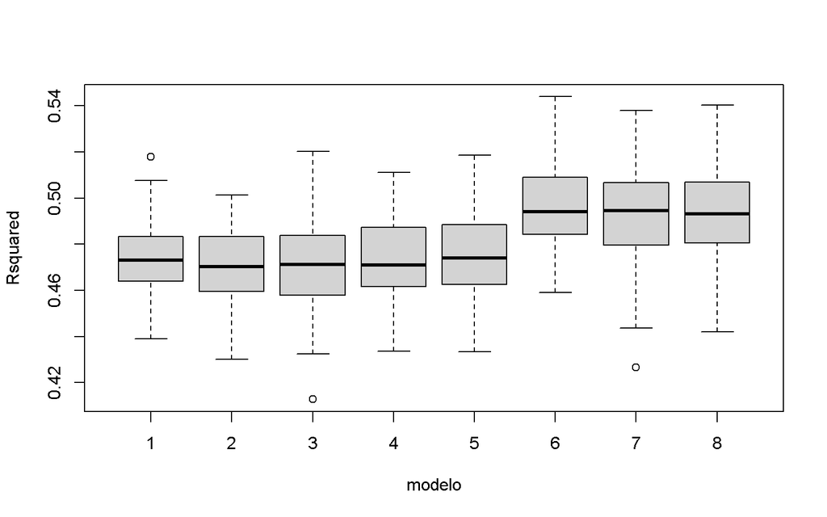

```r
results<-data.frame(rbind(modelo1VC$resample,modelo2VC$resample,modelo3VC$resample,modelo4VC$resample,
                          modelo5VC$resample,modelo6VC$resample,modelo7VC$resample,modelo8VC$resample),
                    modelo=c(rep(1,100),rep(2,100),rep(3,100),rep(4,100),
                              rep(5,100),rep(6,100),rep(7,100),rep(8,100)))
boxplot(Rsquared~modelo,data=results)
```

```r
aggregate(Rsquared~modelo, data = results, mean) #el 4 tiene mayor R2 medio
```

```
##   modelo  Rsquared
## 1      1 0.4739456
## 2      2 0.4709854
## 3      3 0.4713445
## 4      4 0.4735747
## 5      5 0.4752256
## 6      6 0.4962859
## 7      7 0.4943694
## 8      8 0.4930694
```

```r
aggregate(Rsquared~modelo, data = results, sd) #tb tiene mayor variabilidad
```

```
##   modelo   Rsquared
## 1      1 0.01460632
## 2      2 0.01664508
## 3      3 0.02007829
## 4      4 0.01729875
## 5      5 0.01814854
## 6      6 0.01744803
## 7      7 0.02246232
## 8      8 0.01948582
```

```r
length(coef(modelo1_t));length(coef(modelo2));length(coef(modelo3));length(coef(modelo4))
```

```
## [1] 25
```

```
## [1] 11
```

```
## [1] 10
```

```
## [1] 12
```

```r
length(coef(modelo5));length(coef(modelo6));length(coef(modelo7));length(coef(modelo8))
```

```
## [1] 15
```

```
## [1] 31
```

```
## [1] 26
```

```
## [1] 23
```

En este punto hay que decidir un modelo final. Cosa que no es fácil en este caso.

Es evidente que el modelo que mejor capacidad predictiva presenta en relación sesgo-varianza es el modelo6, aquel que tiene la interacción con categorías vacías…Esto a nivel interpretativo es muy difícil de justificar ya que no se podrá cuantificar la influencia de la pertenencia conjunta a las categorías **** y etiqueta MM… Esto hace que el modelo sea ciertamente inconsistente.

Ante esta revelación y teniendo en cuenta que el aumento en R2 es del orden de milésimas en relación a los más cercanos (7 y 8 con interacciones pero con categorías unidas si variables continuas y con ellas), será más prudente desechar este modelo y escoger algún otro.

Valorando la relación entre los modelos con y sin interacciones, el aumento del R2 se sitúa en torno a 2 centésimas pero el número de parámetros se dobla prácticamente…En este sentido, si valoramos la interpretabilidad por encima de un pequeño aumento de la capacidad predictiva, escogeríamos el modelo 4 o 5 que no tiene esta interacción con efectos masivos y un R2 un poco por debajo.

En caso de preferir la mejor capacidad predictiva habría que luchar la interpretación del modelo complejo.

En nuestro caso preferiremos el modelo competitivo más simple, el modelo 4 con 12 parámetros y R2 de 0.473 en cv.

```r
#Evaluamos la estabilidad del modelo a partir de las diferencias en train y test:
Rsq(modelo4,"varObjCont",data_train)
```

```
## $r2
## [1] 0.4720457
##
## $r2_adj
## [1] 0.4707988
```

```r
Rsq(modelo4,"varObjCont",data_test)
```

```
## $r2
## [1] 0.4867726
##
## $r2_adj
## [1] 0.4818769
```

```r
# Vemos las variables más importantes del modelo ganador
modelEffectSizes(modelo4)
```

```
## lm(formula = varObjCont ~ Clasificacion + Etiqueta + CalifProd_cont +
##     Azucar_tree, data = data_train)
##
## Coefficients
##                      SSR df pEta-sqr dR-sqr
## (Intercept)    109184573  1   0.2990     NA
## Clasificacion  147498328  4   0.3656 0.3042
## Etiqueta        16940435  4   0.0621 0.0349
## CalifProd_cont   7993196  1   0.0303 0.0165
## Azucar_tree      1127254  2   0.0044 0.0023
##
## Sum of squared errors (SSE): 255951659.2
## Sum of squared total  (SST): 484798924.6
```

```
## lm(formula = varObjCont ~ Clasificacion + Etiqueta + CalifProd_cont +
##     Azucar_tree, data = data_train)
##
## Coefficients
##                      SSR df pEta-sqr dR-sqr
## (Intercept)    109184573  1   0.2990     NA
## Clasificacion  147498328  4   0.3656 0.3042
## Etiqueta        16940435  4   0.0621 0.0349
## CalifProd_cont   7993196  1   0.0303 0.0165
## Azucar_tree      1127254  2   0.0044 0.0023
##
## Sum of squared errors (SSE): 255951659.2
## Sum of squared total  (SST): 484798924.6
```

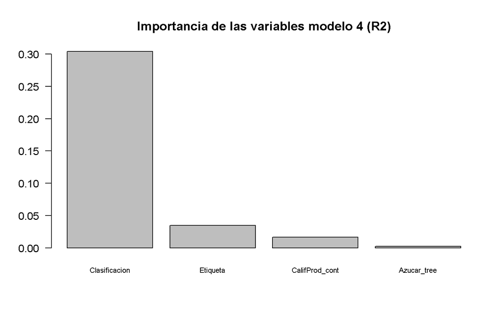

```r
barplot(sort(modelEffectSizes(modelo4)$Effects[-1,4],decreasing =T),las=1, cex.names = 0.7,main="Importancia de las variables modelo 4 (R2)")
```

La variable más importante es clasificación con mucha diferencia

## Ajuste del modelo final. Interpretación de parámetros

Una vez escogido el modelo final. Hay que interpretar sus parámetros teniendo en cuenta que la estimación más robusta de los mismos será la que se obtiene utilizando el datset completo y no solamente las instancias del conjunto de training.

De esta forma, se ajusta el modelo 4 a los datos completos.

**NOTA**: Es útil poder cambiar los niveles de referencia de los factores (variables categóricas o nominales) incluídas en el modelo para una interpretación más cómoda o que se adecúa mejor a la realidad de los datos. Para ello, podemos hacer uso de la función *relevel()*

```r
# Clasificación con nivel de referencia *
todo$Clasificacion <- relevel(todo$Clasificacion, ref = "*")
#todo$Etiqueta <- relevel(todo$Etiqueta, ref = "MM")

# Para etiqueta utilizamos volvemos a especificar orden de niveles si es que el cambio que hicimos en el script de depuración no se ha conservado
todo$Etiqueta<-factor(todo$Etiqueta, levels = c('MM','M','R','B','MB'))
```

```r
modeloFinal<-lm(formula(modelo4),data=todo)
summary(modeloFinal)
```

```
##
## Call:
## lm(formula = formula(modelo4), data = todo)
##
## Residuals:
##     Min      1Q  Median      3Q     Max
## -696.59 -164.50  -14.58  148.54 1014.02
##
## Coefficients:
##                          Estimate Std. Error t value Pr(>|t|)
## (Intercept)               367.621     15.971  23.018  < 2e-16 ***
## Clasificacion**           148.825      7.893  18.856  < 2e-16 ***
## Clasificacion***          241.853      9.165  26.389  < 2e-16 ***
## Clasificacion****         344.903     14.187  24.311  < 2e-16 ***
## ClasificacionDesconocido -205.781      7.958 -25.860  < 2e-16 ***
## EtiquetaM                  65.322     15.107   4.324 1.56e-05 ***
## EtiquetaR                 129.684     14.734   8.801  < 2e-16 ***
## EtiquetaB                 207.194     15.434  13.425  < 2e-16 ***
## EtiquetaMB                274.142     20.635  13.285  < 2e-16 ***
## CalifProd_cont            -31.333      2.181 -14.366  < 2e-16 ***
## Azucar_tree1.62-4.45      -43.946      8.655  -5.078 3.93e-07 ***
## Azucar_tree>4.45            2.433      6.175   0.394    0.694
## ---
## Signif. codes:  0 '***' 0.001 '**' 0.01 '*' 0.05 '.' 0.1 ' ' 1
##
## Residual standard error: 223.6 on 6353 degrees of freedom
## Multiple R-squared:  0.4753, Adjusted R-squared:  0.4743
## F-statistic: 523.1 on 11 and 6353 DF,  p-value: < 2.2e-16
```

```r
# Clasificación con nivel de referencia *
todo$Azucar_tree <- relevel(todo$Azucar_tree, ref = "1.62-4.45")
#todo$Etiqueta <- relevel(todo$Etiqueta, ref = "MM")

modeloFinal2<-lm(formula(modelo4),data=todo)
summary(modeloFinal2)
```

```
##
## Call:
## lm(formula = formula(modelo4), data = todo)
##
## Residuals:
##     Min      1Q  Median      3Q     Max
## -696.59 -164.50  -14.58  148.54 1014.02
##
## Coefficients:
##                          Estimate Std. Error t value Pr(>|t|)
## (Intercept)               323.675     17.276  18.735  < 2e-16 ***
## Clasificacion**           148.825      7.893  18.856  < 2e-16 ***
## Clasificacion***          241.853      9.165  26.389  < 2e-16 ***
## Clasificacion****         344.903     14.187  24.311  < 2e-16 ***
## ClasificacionDesconocido -205.781      7.958 -25.860  < 2e-16 ***
## EtiquetaM                  65.322     15.107   4.324 1.56e-05 ***
## EtiquetaR                 129.684     14.734   8.801  < 2e-16 ***
## EtiquetaB                 207.194     15.434  13.425  < 2e-16 ***
## EtiquetaMB                274.142     20.635  13.285  < 2e-16 ***
## CalifProd_cont            -31.333      2.181 -14.366  < 2e-16 ***
## Azucar_tree<1.62           43.946      8.655   5.078 3.93e-07 ***
## Azucar_tree>4.45           46.379      8.283   5.599 2.25e-08 ***
## ---
## Signif. codes:  0 '***' 0.001 '**' 0.01 '*' 0.05 '.' 0.1 ' ' 1
##
## Residual standard error: 223.6 on 6353 degrees of freedom
## Multiple R-squared:  0.4753, Adjusted R-squared:  0.4743
## F-statistic: 523.1 on 11 and 6353 DF,  p-value: < 2.2e-16
```

**NOTA**: Llegados a este punto, observamos que la categoría de azucar mayor que 4.45 no parece significativamente distinta (en cuanto a efecto sobre la variable respuesta) que la categoría de referencia (<1.62). Podemos fijar el nivel de referencia en valores intermedios y volver a evaluar.

```r
# Clasificación con nivel de referencia *
todo$Azucar_tree <- car::recode(todo$Azucar_tree, "c('<1.62','>4.45') = '<1.62|>4.45'")
#todo$Etiqueta <- relevel(todo$Etiqueta, ref = "MM")

modeloFinal3<-lm(formula(modelo4),data=todo)
summary(modeloFinal3)
```

```
##
## Call:
## lm(formula = formula(modelo4), data = todo)
##
## Residuals:
##     Min      1Q  Median      3Q     Max
## -698.09 -165.89  -14.88  148.93 1012.55
##
## Coefficients:
##                          Estimate Std. Error t value Pr(>|t|)
## (Intercept)               369.048     15.554  23.727  < 2e-16 ***
## Clasificacion**           148.850      7.892  18.861  < 2e-16 ***
## Clasificacion***          241.859      9.164  26.392  < 2e-16 ***
## Clasificacion****         345.019     14.183  24.326  < 2e-16 ***
## ClasificacionDesconocido -205.790      7.957 -25.863  < 2e-16 ***
## EtiquetaM                  65.284     15.105   4.322 1.57e-05 ***
## EtiquetaR                 129.634     14.733   8.799  < 2e-16 ***
## EtiquetaB                 207.139     15.432  13.423  < 2e-16 ***
## EtiquetaMB                274.167     20.634  13.287  < 2e-16 ***
## CalifProd_cont            -31.325      2.181 -14.364  < 2e-16 ***
## Azucar_tree1.62-4.45      -45.363      7.872  -5.763 8.66e-09 ***
## ---
## Signif. codes:  0 '***' 0.001 '**' 0.01 '*' 0.05 '.' 0.1 ' ' 1
##
## Residual standard error: 223.6 on 6354 degrees of freedom
## Multiple R-squared:  0.4752, Adjusted R-squared:  0.4744
## F-statistic: 575.4 on 10 and 6354 DF,  p-value: < 2.2e-16
```

La diferencia es prácticamente inapreciable en el modelo. El R2 ajustado aumenta una diezmilésima…poca cosa. Cuaquiera de las elecciones podría ser válida y depende de la conveniencia a la hora de interpretar.

Decidimos conservar esa pequeña diferencia entre vinos de azucar alto y bajo para tener una interpetación más ordinal de esta característica. Con lo cual escogemos el modeloFinal2.

```r
summary(modeloFinal2)
```

```
##
## Call:
## lm(formula = formula(modelo4), data = todo)
##
## Residuals:
##     Min      1Q  Median      3Q     Max
## -696.59 -164.50  -14.58  148.54 1014.02
##
## Coefficients:
##                          Estimate Std. Error t value Pr(>|t|)
## (Intercept)               323.675     17.276  18.735  < 2e-16 ***
## Clasificacion**           148.825      7.893  18.856  < 2e-16 ***
## Clasificacion***          241.853      9.165  26.389  < 2e-16 ***
## Clasificacion****         344.903     14.187  24.311  < 2e-16 ***
## ClasificacionDesconocido -205.781      7.958 -25.860  < 2e-16 ***
## EtiquetaM                  65.322     15.107   4.324 1.56e-05 ***
## EtiquetaR                 129.684     14.734   8.801  < 2e-16 ***
## EtiquetaB                 207.194     15.434  13.425  < 2e-16 ***
## EtiquetaMB                274.142     20.635  13.285  < 2e-16 ***
## CalifProd_cont            -31.333      2.181 -14.366  < 2e-16 ***
## Azucar_tree<1.62           43.946      8.655   5.078 3.93e-07 ***
## Azucar_tree>4.45           46.379      8.283   5.599 2.25e-08 ***
## ---
## Signif. codes:  0 '***' 0.001 '**' 0.01 '*' 0.05 '.' 0.1 ' ' 1
##
## Residual standard error: 223.6 on 6353 degrees of freedom
## Multiple R-squared:  0.4753, Adjusted R-squared:  0.4743
## F-statistic: 523.1 on 11 and 6353 DF,  p-value: < 2.2e-16
```

Todas estas afirmaciones se hacen a constancia de todas las demás variables involucradas en el modelo (ceteris paribus), es decir, se valora el cambio marginal que tiene cada variable para valores fijos de todas las demás.

Así, ese aumento en los vinos de **** se da en aquellos que tienen la misma etiqueta, misma calificación del productor y mismo nivel de azúcar.